# Epigenomic experiments in Ensembl 114

Gabriela Merino - Ensembl Regulation

2025-09-19

This script is aimed to explore the number of ATAC-seq, DNase-seq and ChIP-seq experiments processed with the Ensembl Regulation [primary analysis pipeline](https://regulation.ensembl.org/help/primary_processing) and released in [Ensembl 114](https://ftp.ensembl.org/pub/release-114/regulation/).

**Note**: If you plan to run this script you need to update the following command to replace `/your/full/path/to/` with the full path to the repository folder in your computer.

```r
my_path = "/your/full/path/to/regulation-manuscript-tenspecies/experiments-analysis"
knitr::opts_knit$set(root.dir = my_path)
# setwd(my_path) # optional if running interactively
```

Loading required libraries.

```r
library(dplyr)
library(tidyr)
library(stringr)
library(ggplot2)
library(cowplot)
library(ggh4x)
```

The table summarising the experiments metadata is available in the regulation-manuscript-tenspecies/experiments-analysis/data folder and it has been built based on information retrieved from the `Regulation Data Registry` database.

Experiments metadata is available for the ten species included in Ensembl 114: *human, mouse, pig, chicken, cattle, Atlantic salmon, rainbow trout, turbot, European seabass, and common carp.*

```r
read.delim(file = 'data/epigenomic_experiments_metadata_e114.tsv',
            sep = '\t', header = T) -> experimentsMetadata
```

Number of experiments per species

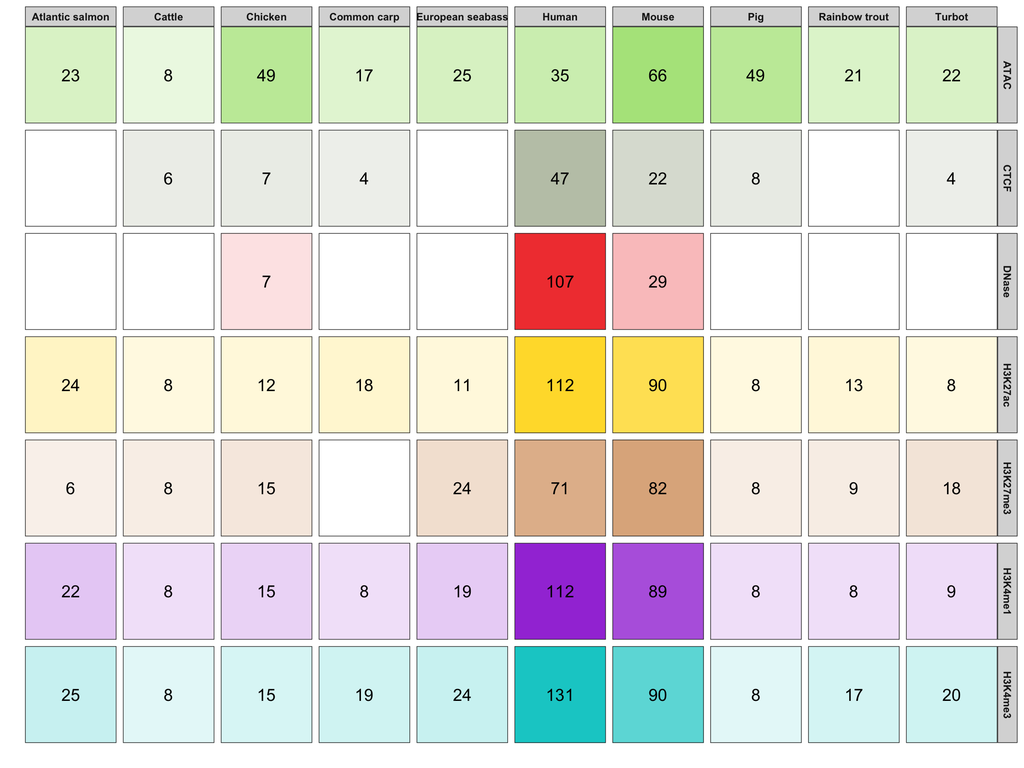

```r
experimentsMetadata %>%
  select(species, experiment_target) %>%
  group_by(species, experiment_target) %>%
  summarise( n = n()) %>% as.data.frame() -> dfPlot
markCols <- c('chartreuse3', 'darkolivegreen', 'red2', 'gold', 'peru',
              'darkviolet', 'cyan3')
names(markCols) <- levels(dfPlot$experiment_target)

g <- ggplot(dfPlot) +
      geom_bar(aes(x = 1, y = 1,
                   # color = species,
                   fill = experiment_target, alpha = n), stat = 'identity',
               position = position_dodge(width = 1)) +
      geom_text(aes( x = 1, y = 0.5, label = n), size = 5) +
      facet_nested( experiment_target ~ species,
                    scales = 'free_x', drop = TRUE, space = 'free') +
      theme_bw() +  coord_cartesian(expand = FALSE) +
      labs(x = '', y = '', fill = '', color = '') +
      theme(legend.position = 'none', axis.text.x = element_blank(),
            axis.ticks.x = element_blank(), axis.text.y = element_blank(),
            axis.ticks.y = element_blank(), panel.grid = element_blank(),
            strip.text.x = element_text(face = 'bold'),
            strip.text.y = element_text(face = 'bold')) +
      scale_fill_manual(values = markCols)

g
```

Removing H3K27me3 and combining open chromatin data

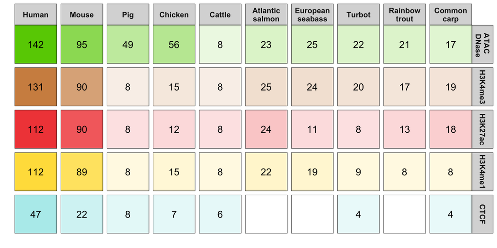

```r
experimentsMetadata %>%
  filter(experiment_target != 'H3K27me3') %>%
  select(species, experiment_target) %>%
  mutate(experiment_target = if_else(experiment_target %in% c('ATAC','DNase'),
                                     'ATAC \n DNase', experiment_target)) %>%
  mutate(species = str_replace_all(species, ' ', '\n')) %>%
  group_by(species, experiment_target) %>%
  summarise( n = n()) %>% as.data.frame() ->dfPlot

dfPlot %>%
  mutate(experiment_target = factor(experiment_target,
                                    levels = c("ATAC \n DNase","H3K4me3",
                                               "H3K27ac", "H3K4me1",
                                               "CTCF"))) %>%
  mutate(species = factor(species, levels = c("Human", "Mouse", "Pig",
                                              "Chicken", "Cattle",
                                              "Atlantic\nsalmon",
                                               "European\nseabass", "Turbot",
                                              "Rainbow\ntrout",
                                              "Common\ncarp")))-> dfPlot
markCols <- c('chartreuse3', 'red2', 'gold', 'peru','cyan3')
names(markCols) <- unique(dfPlot$experiment_target)

g <- ggplot(dfPlot) +
      geom_bar(aes(x = 1, y = 1,
                   fill = experiment_target, alpha = n), stat = 'identity',
               position = position_dodge(width = 1)) +
      geom_text(aes( x = 1, y = 0.5, label = n), size = 5) +
      facet_nested( experiment_target ~ species,
                    scales = 'free_x', drop = TRUE, space = 'free') +
      theme_bw() +  coord_cartesian(expand = FALSE) +
      labs(x = '', y = '', fill = '', color = '') +
      theme(legend.position = 'none', axis.text.x = element_blank(),
            axis.ticks.x = element_blank(), axis.text.y = element_blank(),
            axis.ticks.y = element_blank(), panel.grid = element_blank(),
            strip.text.x = element_text(size = 11,face = 'bold'),
            strip.text.y = element_text(size = 11,face = 'bold')
            ) +
      scale_fill_manual(values = markCols)
g
```

Number of experiments per biomaterial type and per species:

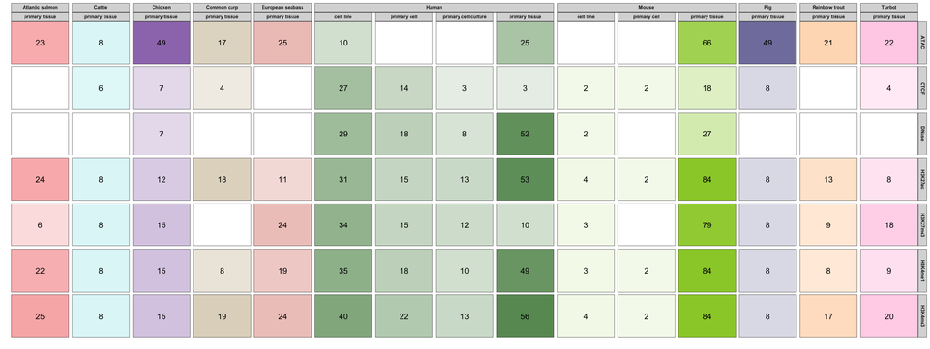

```r
experimentsMetadata %>%
  select(species, experiment_target, biomaterial_type,
         life_stage_term, sex) %>%
  group_by(species, experiment_target, biomaterial_type) %>%
  summarise( n = n()) %>% as.data.frame() ->dfPlot

speciesMap <- c('Human', 'Mouse', 'Pig', 'Chicken', 'Cattle', 'Atlantic salmon',
                'Rainbow trout', 'Turbot', 'European seabass', 'Common carp')
names(speciesMap)<- c('Homo sapiens', 'Mus musculus', 'Sus scrofa',
                      'Gallus gallus', 'Bos taurus', 'Salmo salar',
                      'Oncorhynchus mykiss', 'Scophthalmus maximus',
                      'Dicentrarchus labrax', 'Cyprinus carpio carpio')

specCols <- c('darkgreen', 'olivedrab3', 'midnightblue',
              'purple4','darkturquoise', 'red2','darkorange', 'hotpink', 'tomato3',
              'darkgoldenrod4')
names(specCols) <- speciesMap

g <- ggplot(dfPlot) +
      geom_bar(aes(x = 1, y = 1,
                   fill = species, alpha = n), stat = 'identity',
               position = position_dodge(width = 1)) +
      geom_text(aes( x = 1, y = 0.5, label = n), size = 5) +
      facet_nested( experiment_target ~ species + biomaterial_type,
                    scales = 'free_x', drop = TRUE, space = 'free') +
      theme_bw() +  coord_cartesian(expand = FALSE) +
      labs(x = '', y = '', fill = '', color = '') +
      theme(legend.position = 'none', axis.text.x = element_blank(),
            axis.ticks.x = element_blank(), axis.text.y = element_blank(),
            axis.ticks.y = element_blank(), panel.grid = element_blank(),
            strip.text.x = element_text(face = 'bold'),
            strip.text.y = element_text(face = 'bold')) +
      scale_fill_manual(values = specCols)
g
```

Parsing tissues names or biosample terms in order to define `biosample groups` of epigenomes from cell lines and closely-related tissues:

```r
experimentsMetadata %>%
  mutate(biosample_group = if_else(biosample_term == 'immature gonad',
                                  'gonad', biosample_term)) %>%
  mutate(biosample_group = if_else(grepl('adipose', biosample_group),
                        'adipose', biosample_group)) %>%
  mutate(biosample_group = if_else(grepl('brain', biosample_group) |
                                     grepl('brain', organ_slims) |
                                     grepl('cortex', biosample_group) |
                                     grepl('cerebellum', biosample_group) |
                                     grepl('hypothalamus', biosample_group) |
                                     grepl('neural progenitor',biosample_group),
                                   'brain', biosample_group)) %>%
  mutate(biosample_group = if_else(grepl('neuron', biosample_group),
                                   'neural cell', biosample_group)) %>%
  mutate(biosample_group = if_else(grepl('heart', biosample_group) |
                                     grepl('heart', organ_slims), 'heart',
                                   biosample_group)) %>%
  mutate(biosample_group = if_else(grepl('tibial nerve', biosample_group),
                                   'limb', biosample_group)) %>%
  mutate(biosample_group = if_else(grepl('lung', organ_slims) |
                                     grepl('lung', biosample_group), 'lung',
                                   biosample_group)) %>%
  mutate(biosample_group = if_else(grepl('pancreas', organ_slims), 'pancreas',
                                   biosample_group)) %>%
  mutate(biosample_group = if_else(grepl('intestine', organ_slims) |
                                     grepl('ileum', biosample_group) |
                                     grepl('intestine', biosample_group),
                                   'intestine', biosample_group)) %>%
  mutate(biosample_group = if_else(grepl('muscle', biosample_group) |
                                     grepl('musculature', organ_slims) |
                                     grepl('gluteus', biosample_group) |
                                     grepl('skeletal', biosample_group) |
                                     grepl('longissimus', biosample_group),
                                   'muscle', biosample_group)) %>%
  mutate(biosample_group = if_else(grepl('stomach', organ_slims),
                                   'stomach', biosample_group)) %>%
  mutate(biosample_group = if_else(grepl('spleen', organ_slims) |
                                     grepl('thymus', organ_slims) |
                                     grepl('spleen', biosample_group) |
                                     grepl('hymus', biosample_group),
                                   'immune organ', biosample_group)) %>%
  mutate(biosample_group = if_else(grepl('endocrine', organ_slims),
                                   'endocrine gland', biosample_group)) %>%
  mutate(biosample_group = if_else(grepl('testis', biosample_group) |
                                     grepl('testis', organ_slims), 'gonad',
                                   biosample_group)) %>%
  mutate(biosample_group = if_else(grepl('epithel', organ_slims),
                                   'epithelium', biosample_group)) %>%
  mutate(biosample_group = if_else(grepl('kidney', organ_slims) |
                                     grepl('kidney', biosample_group) |
                                     grepl('mesonephros', biosample_group),
                                   'kidney', biosample_group)) %>%
  mutate(biosample_group = if_else(grepl('liver', organ_slims) |
                                     grepl('liver', biosample_group), 'liver',
                                   biosample_group)) %>%
  mutate(biosample_group = if_else(grepl('embryo', organ_slims), 'embryonic',
                                   biosample_group)) %>%
  mutate(biosample_group = if_else(grepl('skin', biosample_group) |
                                     grepl('skin', organ_slims), 'skin',
                                   biosample_group)) %>%
  mutate(biosample_group = if_else(grepl('blood vessel', organ_slims),
                                   'blood vessel', biosample_group)) %>%
  mutate(biosample_group = if_else(grepl('tibial nerve', organ_slims), 'limb',
                                   biosample_group)) %>%
  mutate(biosample_group = if_else(grepl('bone marrow', organ_slims),
                                   'bone marrow', biosample_group)) %>%
  mutate(biosample_group = if_else(grepl('blood', organ_slims) |
                                     grepl('B cell', cell_slims)|
                                     (grepl('hematopoietic', cell_slims)  &
                                        !(grepl('bone marrow',
                                                experimentsMetadata$biosample_term))),
                                   'blood', biosample_group)) %>%
  mutate(biosample_group = if_else(grepl('connective tissue', organ_slims),
                                   'connective tissue', biosample_group)) %>%
  mutate(biosample_group = if_else(grepl('terus', biosample_group) |
                                     grepl('prostate', organ_slims) |
                                     grepl('vagina', organ_slims),
                                   'reproductive', biosample_group)
         ) -> experimentsMetadata
```

Number of experiment per biosample group and per species:

```r
experimentsMetadata %>%
  select(species, experiment_target, biosample_group,
          life_stage_term, sex) %>%
  group_by(species, experiment_target, biosample_group) %>%
  summarise( n = n()) %>% as.data.frame() ->dfPlot

markCols <- c('chartreuse3', 'darkolivegreen', 'red2', 'gold', 'peru',
              'darkviolet', 'cyan3')
names(markCols) <- levels(dfPlot$experiment_target)
dfPlot %>%
  arrange(desc(biosample_group))-> dfPlot
dfPlot[,'biosample_group'] <- factor(dfPlot[,'biosample_group'],
                                     levels = unique(dfPlot$biosample_group))
```

Figure **1a**: Tetrapods

```r
tetrapods <- c('Human', 'Mouse', 'Pig', 'Chicken', 'Cattle')
alphaScale <- c('0', '1','2-5','>5')

dfPlot %>%
  filter(species %in% tetrapods) %>%
  mutate(nDisc = cut(n, breaks = c(-Inf,0,1,5,Inf),
                     labels = alphaScale)) %>%
  ggplot() +
  geom_tile(aes(x = experiment_target, y = biosample_group,
                fill = experiment_target, alpha = nDisc)) +
  geom_text(aes( x = experiment_target, y = biosample_group, label = n),
            size = 3) +
  facet_wrap(~ species,  drop = TRUE, nrow = 1 ) +
  coord_cartesian(expand = FALSE)  +
  theme_bw() +
  theme(legend.position = 'none', axis.text.x = element_blank(),
        axis.ticks.x = element_blank(),
        axis.ticks.y = element_blank(), panel.grid = element_blank(),
        strip.text.x = element_text(face = 'bold'),
        strip.text.y = element_text(face = 'bold'),
        strip.background = element_blank(),
        panel.background = element_rect(fill = 'white'))+
  scale_fill_manual(values = markCols) +
  scale_alpha_discrete(c(0,1), name = '# of experiments') +
  guides(fill = guide_legend(nrow = 1), alpha =guide_legend(nrow = 1) ) +
  labs(x = '', y = '', fill = '') -> tetrapods_plot
```

Extracting plot legends:

```r
tetrapods_legend <-get_plot_component(tetrapods_plot +
                                        theme(legend.position = 'bottom')+
                                       guides(alpha = 'none'),
                                      'guide-box', return_all = TRUE)
```

Figure **1a**: Fishes

```r
fishes <- c('Atlantic salmon', 'Common carp', 'European seabass',
            'Rainbow trout', 'Turbot')

dfPlot %>%
  filter(species %in% fishes) %>%
  mutate(nDisc = cut(n, breaks = c(-Inf,0,1,5,Inf),
                     labels = alphaScale)) %>%
  ggplot() +
  geom_tile(aes(x = experiment_target, y = biosample_group,
                fill = experiment_target, alpha = nDisc)) +
  geom_text(aes( x = experiment_target, y = biosample_group, label = n),
            size = 3) +
  facet_wrap(~ species,  drop = TRUE, nrow = 1 ) +
  coord_cartesian(expand = FALSE)  +
  theme_bw() +
  theme(legend.position = 'bottom', axis.text.x = element_blank(),
        axis.ticks.x = element_blank(),
        axis.ticks.y = element_blank(), panel.grid = element_blank(),
        strip.text.x = element_text(face = 'bold'),
        strip.text.y = element_text(face = 'bold'),
        strip.background = element_blank(),
        panel.background = element_rect(fill = 'white'))+
  scale_fill_manual(values = markCols) +
  scale_alpha_discrete(c(0,1), name = '# of experiments') +
  guides(fill = guide_legend(nrow = 1), alpha =guide_legend(nrow = 1) ) +
  labs(x = '', y = '', fill = '') -> fishes_plot
```

Arranging both panel in a single figure:

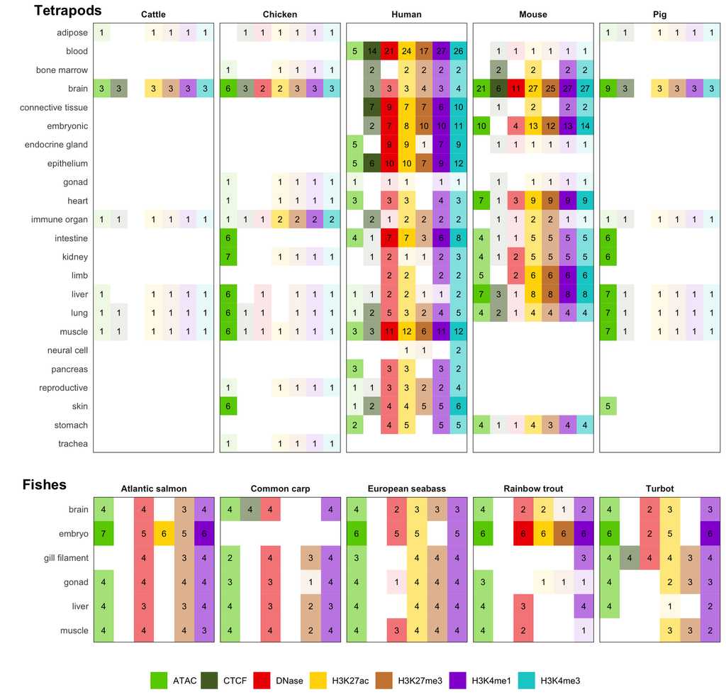

```r
Figure_1_a <- plot_grid(plot_grid(tetrapods_plot,
                    # adding and empty plot just for adjusting margins
                    plot_grid(ggplot() +
                                theme(panel.background =
                                        element_rect (fill = 'white')),
                              fishes_plot +
                                theme(legend.position = 'none'), nrow =1,
                              rel_widths = c(0.035,1)),
                    labels = c('Tetrapods', 'Fishes'),
                    nrow = 2, rel_heights = c(1,0.4)),
                    # adding legend
                    tetrapods_legend,
                    nrow =2, rel_heights = c(1, 0.05))
Figure_1_a
```